# Reproducible Research - Assignment 1

Abraham Aizenman

Wednesday, August 13, 2014

# Reproducible Research: Peer Assessment 1

First get the working directory

```r
setwd("C:/PredictiveAnalysis/R")
```

## Loading and preprocessing the data

Read in the data.

```r
activity<-read.csv("activity.csv")
```

Find out the type of fields of the activity file, examine the data

```r
str(activity)
```

‘data.frame’: 17568 obs. of 3 variables: $ steps : int NA NA NA NA NA NA NA NA NA NA … $ date : Factor w/ 61 levels “2012-10-01”,“2012-10-02”,..: 1 1 1 1 1 1 1 1 1 1 … $ interval: int 0 5 10 15 20 25 30 35 40 45 …

```r
summary(activity)
```

```
 steps               date          interval
```

Min. : 0.0 2012-10-01: 288 Min. : 0  
1st Qu.: 0.0 2012-10-02: 288 1st Qu.: 589  
Median : 0.0 2012-10-03: 288 Median :1178  
Mean : 37.4 2012-10-04: 288 Mean :1178  
3rd Qu.: 12.0 2012-10-05: 288 3rd Qu.:1766  
Max. :806.0 2012-10-06: 288 Max. :2355  
NA’s :2304 (Other) :15840  
We find that we have to change the date column to date and to accomodate the date format

```r
activity$date <- as.Date(activity$date)
```

## What is mean total number of steps taken per day?

- For this part of the assignment, I am ignoring the missing values in the dataset.

```r
activity.ignore.na <- na.omit(activity)
```

- Make a histogram of the total number of steps taken each day

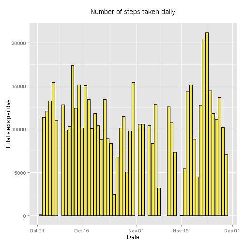

```r
steps.by.date<-aggregate(steps ~ date, data = activity.ignore.na, FUN = sum)
library(ggplot2)
qplot(x=steps.by.date$date, y=steps.by.date$steps, data=steps.by.date, geom='bar', stat='identity')+ geom_bar(fill="#F0E442", colour="black", stat="identity")+ labs(title='Number of steps taken daily\n',y='Total steps per day', x='Date')
```

- Calculate and report the mean and median total number of steps taken per day

```r
## Mean
mean(steps.by.date$steps)
```

[1] 10766

```r
## Median
median(steps.by.date$steps)
```

[output not shown]

- First, we will calculate the average of each interval for the 24 hours period

```r
library(plyr)
mean.steps.by.interval <- ddply(activity.ignore.na,~interval,summarise,mean=mean(steps))
```

- Second, make the plot

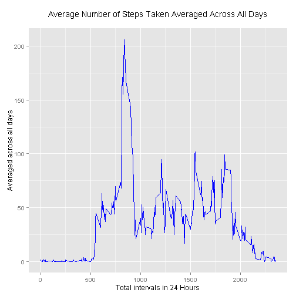

```r
qplot(x=mean.steps.by.interval$interval, y=mean.steps.by.interval$mean, data=mean.steps.by.interval, geom='line')+ geom_line(colour="blue", stat="identity")+ labs(title='Average Number of Steps Taken Averaged Across All Days\n',y='Averaged across all days', x='Total intervals in 24 Hours')
```

2. Which 5-minute interval, on average across all the days in the dataset, contains the maximum number of steps?

```r
mean.steps.by.interval[which.max( mean.steps.by.interval$mean ),1]
```

[output not shown]

```r
apply(activity, 2, function(x) length(which(is.na(x))))
```

steps date interval 2304 0 0

```r
### or
summary(activity)
```

```
 steps            date               interval
```

Min. : 0.0 Min. :2012-10-01 Min. : 0  
1st Qu.: 0.0 1st Qu.:2012-10-16 1st Qu.: 589  
Median : 0.0 Median :2012-10-31 Median :1178  
Mean : 37.4 Mean :2012-10-31 Mean :1178  
3rd Qu.: 12.0 3rd Qu.:2012-11-15 3rd Qu.:1766  
Max. :806.0 Max. :2012-11-30 Max. :2355  
NA’s :2304

2. Devise a strategy for filling in all of the missing values in the dataset. The strategy does not need to be sophisticated. For example, you could use the mean/median for that day, or the mean for that 5-minute interval, etc. ### I will use the mean for the 5-minute intervals as fillers for missing values.

```r
activity <- merge(activity, mean.steps.by.interval, by = "interval")
the_nas<-is.na(activity$steps)
activity$steps[the_nas]<-activity$mean[the_nas]
```

3. Create a new dataset that is equal to the original dataset but with the missing data filled in.

```r
activity <- activity[, c(1:3)]
```

4. Make a histogram of the total number of steps taken each day and Calculate and report the mean and median total number of steps taken per day. Do these values differ from the estimates from the first part of the assignment? What is the impact of imputing missing data on the estimates of the total daily number of steps?

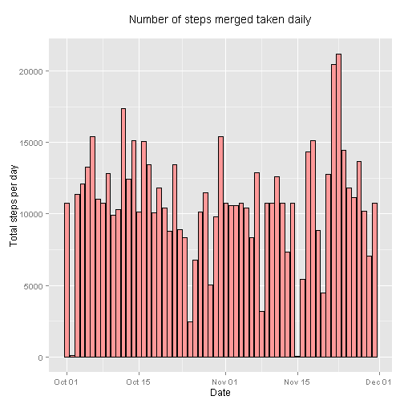

```r
steps.by.date.merged<-aggregate(steps ~ date, data = activity, FUN = sum)
qplot(x=steps.by.date.merged$date, y=steps.by.date.merged$steps, data=steps.by.date.merged, geom='bar', stat='identity')+ geom_bar(fill="#FF9999", colour="black", stat="identity")+ labs(title='Number of steps merged taken daily\n',y='Total steps per day', x='Date')
```

- Calculate and report the mean and median total number of merged steps taken per day

```r
## Mean
mean(steps.by.date.merged$steps)
```

[1] 10766

```r
## Median
median(steps.by.date.merged$steps)
```

[1] 10766 - These received values (mean and median) did not differ from the estimates from the first part of the assignment. In the Median there was a small difference of 1 unit which is almost very neglible. - The impact of imputing missing data was neglible.

## Are there differences in activity patterns between weekdays and weekends?

1. Create a new factor variable in the dataset with two levels - “weekday” and “weekend” indicating whether a given date is a weekday or weekend day.

```r
daytype <- function(date) {
        if (weekdays(as.Date(date)) %in% c("Saturday", "Sunday")) {
                "weekend"
                } else {
                        "weekday"
                        }
        }

activity$daytype <- as.factor(sapply(activity$date, daytype))
```

```r
weekend.interval<- aggregate(steps ~ interval, data = activity, subset = activity$daytype == "weekend", FUN = mean)
weekday.interval<- aggregate(steps ~ interval, data = activity, subset = activity$daytype == "weekday", FUN = mean)
```

- Second, make the plots

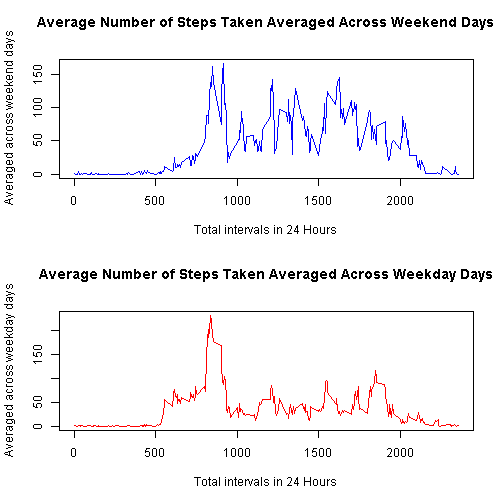

```r
par(mfrow=c(2,1))

plot(weekend.interval$interval,weekend.interval$steps,type="l", col='blue',ylab='Averaged across weekend days', xlab="Total intervals in 24 Hours", main="Average Number of Steps Taken Averaged Across Weekend Days\n")

plot(weekday.interval$interval,weekday.interval$steps,type="l", col='red',ylab='Averaged across weekday days', xlab="Total intervals in 24 Hours", main="Average Number of Steps Taken Averaged Across Weekday Days\n")
```

Final Observations:

There differences btween the activity patterns between weekdays and weekends. The plot indicates that the person moves around more (or more active) during the weekend days.